# Odds Ratio Graphs

- Show All Code
- Hide All Code
- View Source

# Data Import

Odds-ratio parameters and paired comparisons for each predictor, referenced against Class 1 and Class 3 respectively, are read in from the project’s Excel results workbook. Import code is included but not rendered below.

**Note**

The code for this section is collapsed by default, but can be expanded individually for each section or all together with the toggle on the upper right.

# Wrangle Parameter Sheets

```r
pred_labels <- c(
  "female"       = "Sex (Male = 0)",
  "Zwave1age"    = "Age",
  "Zpeer_subuse" = "Peer Substance Use",
  "pub_timing"   = "Pubertal Timing",
  "Zasp"         = "ASP"
)

tidy_params <- function(raw, cluster_cols) {
  raw %>%
    rename_with(~ "predictor_var", 1) %>%
    rename(omnibus_p = `p-value`) %>%
    pivot_longer(
      cols      = all_of(cluster_cols),
      names_to  = "cluster_raw",
      values_to = "log_odds"
    ) %>%
    mutate(
      predictor_label = recode(predictor_var, !!!pred_labels),
      log_odds        = as.numeric(log_odds),
      cluster         = recode(cluster_raw,
                          "Cluster1" = "C1", "Cluster2" = "C2",
                          "Cluster3" = "C3", "Cluster4" = "C4"),
      cluster         = factor(cluster, levels = c("C1", "C2", "C3", "C4")),
      OR              = exp(log_odds)
    ) %>%
    select(predictor_label, predictor_var, cluster, log_odds, OR, omnibus_p)
}

c1_params <- tidy_params(c1_params_raw, c("Cluster1", "Cluster2", "Cluster3", "Cluster4"))
c3_params <- tidy_params(c3_params_raw, c("Cluster3", "Cluster4", "Cluster1", "Cluster2"))
```

# BH Correction on Pairwise Comparisons

```r
apply_bh <- function(raw) {
  raw %>%
    rename(predictor = covariate, p_value = `p-value`) %>%
    filter(predictor != "Intercept") %>%
    mutate(
      p_value = as.numeric(p_value),
      p_adj   = p.adjust(p_value, method = "BH"),
      sig     = p_adj < .05
    )
}

c1_pairs <- apply_bh(c1_pairs_raw)
c3_pairs <- apply_bh(c3_pairs_raw)
```

# Figures: C1 as Reference Group

## Figure: Sex - C1 Reference

```r
c1_sex <- c1_params %>% filter(predictor_var == "female")

ref_sig <- c1_pairs %>%
  filter(predictor == "bio_sexD",
         cluster_a == 1 | cluster_b == 1,
         sig == TRUE) %>%
  mutate(other = ifelse(cluster_a == 1, cluster_b, cluster_a)) %>%
  pull(other)                          # cluster numbers sig different from C1

other_sig <- c1_pairs %>%
  filter(predictor == "bio_sexD",
         cluster_a != 1, cluster_b != 1,
         sig == TRUE) %>%
  mutate(pair = paste0("C", cluster_a, " vs. C", cluster_b)) %>%
  pull(pair)                           # non-reference sig pairs for caption

c1_sex <- c1_sex %>%
  mutate(
    ast_label = ifelse(as.integer(cluster) %in% ref_sig, "*", ""),
    ast_y     = OR + max(OR) * ast_nudge_pct
  )

plot_title   <- "Sex (Female vs. Male)"
x_label      <- "Reference: C1"
y_label      <- "Odds Ratio - C1 as Reference"
fig_caption  <- if (length(other_sig) > 0) {
                  paste0("Additional significant pairwise differences after BH correction (FDR < .05): ",
                         paste(other_sig, collapse = "; "), ".")
              }  else {
                  "No additional pairwise differences were significant after BH correction."
 }
p_c1_sex <- ggplot(c1_sex, aes(x = cluster, y = OR, fill = cluster)) +
  geom_col(width = bar_width, alpha = bar_alpha,
            linewidth = bar_outline_lwd) +
  geom_hline(yintercept = 1, color = ref_line_color,
             linewidth = ref_line_lwd, linetype = ref_line_type) +
  geom_text(aes(y = OR, label = round(OR, 2)),
            color = or_label_color, size = or_label_size, vjust = or_label_vjust) +
  geom_text(aes(y = ast_y, label = ast_label),
            size = ast_text_size, vjust = 0.5) +
  scale_fill_manual(values = cluster_colors) +
  scale_y_continuous(expand = expansion(mult = c(0, 0.18)),
                     labels = number_format(accuracy = 0.1)) +
  labs(title = plot_title, x = x_label, y = y_label, caption = fig_caption) +
  or_theme + theme(plot.caption    = element_text(size = 14, hjust = .5, face = "plain", family = plot_font,
                                   margin = margin(t = 8)),
                    axis.title.x = element_blank() ,
                   axis.text.x = element_text(size = 32),
                   axis.title = element_text(size = 40),
                  axis.title.y = element_blank() )


ggsave(file.path(fig_or_c1, "bio_sexD_OR_C1ref.png"),
       plot = p_c1_sex, width = 14, height = 8, dpi = fig_dpi, units = "in")
```

## Figure: Age - C1 Reference

```r
c1_age <- c1_params %>% filter(predictor_var == "Zwave1age")

ref_sig <- c1_pairs %>%
  filter(predictor == "Zwave1age",
         cluster_a == 1 | cluster_b == 1,
         sig == TRUE) %>%
  mutate(other = ifelse(cluster_a == 1, cluster_b, cluster_a)) %>%
  pull(other)

other_sig <- c1_pairs %>%
  filter(predictor == "Zwave1age",
         cluster_a != 1, cluster_b != 1,
         sig == TRUE) %>%
  mutate(pair = paste0("C", cluster_a, " vs. C", cluster_b)) %>%
  pull(pair)

c1_age <- c1_age %>%
  mutate(
    ast_label = ifelse(as.integer(cluster) %in% ref_sig, "*", ""),
    ast_y     = OR + max(OR) * ast_nudge_pct
  )

plot_title  <- "Age"
x_label     <- "Reference: C1"
y_label     <- y_lab
fig_caption <- if (length(other_sig) > 0) {
                 paste0("Additional significant pairwise differences after BH correction (FDR < .05): ",
                        paste(other_sig, collapse = "; "), ".")
               } else {
                 "No additional pairwise differences were significant after BH correction."
               }
p_c1_age <- ggplot(c1_age, aes(x = cluster, y = OR, fill = cluster)) +
  geom_col(width = bar_width, alpha = bar_alpha,
            linewidth = bar_outline_lwd) +
  geom_hline(yintercept = 1, color = ref_line_color,
             linewidth = ref_line_lwd, linetype = ref_line_type) +
  geom_text(aes(y = OR, label = round(OR, 2)),
            color = or_label_color, size = or_label_size, vjust = or_label_vjust) +
  geom_text(aes(y = ast_y, label = ast_label),
            size = ast_text_size, vjust = 0.5) +
  scale_fill_manual(values = cluster_colors) +
  scale_y_continuous(expand = expansion(mult = c(0, 0.18)),
                     labels = number_format(accuracy = 0.1)) +
  labs(title = plot_title, x = x_label, y = y_label, caption = fig_caption) +
  or_theme + theme(plot.caption    = element_text(size = 14, hjust = .5, face = "plain", family = plot_font,
                                   margin = margin(t = 8)),
                   axis.title.y = element_blank(),
                   axis.title.x = element_blank() ,
                 axis.text.x = element_text(size = 32),
                   axis.title = element_text(size = 40) )


print(p_c1_age)
cat("\n*Caption:*", fig_caption, "\n")
```

```
*Caption:* Additional significant pairwise differences after BH correction (FDR < .05): C2 vs. C3; C2 vs. C4.
```

Figure 1

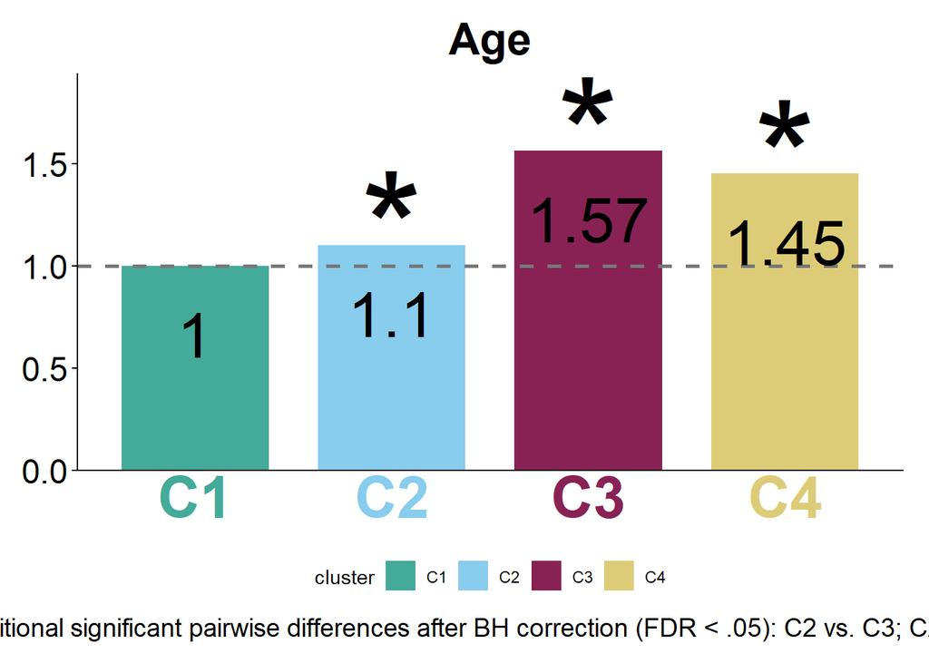

```r
ggsave(file.path(fig_or_c1, "Zwave1age_OR_C1ref.png"),
       plot = p_c1_age, width = 14, height = 8, dpi = fig_dpi, units = "in")
```

## Figure: Peer Substance Use - C1 Reference

```r
c1_peer <- c1_params %>% filter(predictor_var == "Zpeer_subuse")

ref_sig <- c1_pairs %>%
  filter(predictor == "Zpeer_subuse",
         cluster_a == 1 | cluster_b == 1,
         sig == TRUE) %>%
  mutate(other = ifelse(cluster_a == 1, cluster_b, cluster_a)) %>%
  pull(other)

other_sig <- c1_pairs %>%
  filter(predictor == "Zpeer_subuse",
         cluster_a != 1, cluster_b != 1,
         sig == TRUE) %>%
  mutate(pair = paste0("C", cluster_a, " vs. C", cluster_b)) %>%
  pull(pair)

c1_peer <- c1_peer %>%
  mutate(
    ast_label = ifelse(as.integer(cluster) %in% ref_sig, "*", ""),
    ast_y     = OR + max(OR) * ast_nudge_pct
  )

plot_title  <- "Peer Substance Use"
x_label     <- "Reference: C1"
y_label     <- y_lab
fig_caption <- if (length(other_sig) > 0) {
                 paste0("Additional significant pairwise differences after BH correction (FDR < .05): ",
                        paste(other_sig, collapse = "; "), ".")
               } else {
                 "No additional pairwise differences were significant after BH correction."
 }
p_c1_peer <- ggplot(c1_peer, aes(x = cluster, y = OR, fill = cluster)) +
  geom_col(width = bar_width, alpha = bar_alpha,
            linewidth = bar_outline_lwd) +
  geom_hline(yintercept = 1, color = ref_line_color,
             linewidth = ref_line_lwd, linetype = ref_line_type) +
  geom_text(aes(y = OR, label = round(OR, 2)),
            color = or_label_color, size = or_label_size, vjust = or_label_vjust) +
  geom_text(aes(y = ast_y, label = ast_label),
            size = ast_text_size, vjust = 0.5) +
  scale_fill_manual(values = cluster_colors) +
  scale_y_continuous(expand = expansion(mult = c(0, 0.18)),
                     labels = number_format(accuracy = 0.1)) +
  labs(title = plot_title, x = x_label, y = y_label, caption = fig_caption) +
  or_theme +  theme(plot.caption    = element_text(size = 14, hjust = .5, face = "plain", family = plot_font,
                                   margin = margin(t = 8)) ,
                   axis.title.y = element_blank(),
                   axis.title.x = element_blank() ,
                 axis.text.x = element_text(size = 32),
                   axis.title = element_text(size = 40) )

print(p_c1_peer)
cat("\n*Caption:*", fig_caption, "\n")
```

```
*Caption:* Additional significant pairwise differences after BH correction (FDR < .05): C2 vs. C3; C2 vs. C4; C3 vs. C4.
```

Figure 2

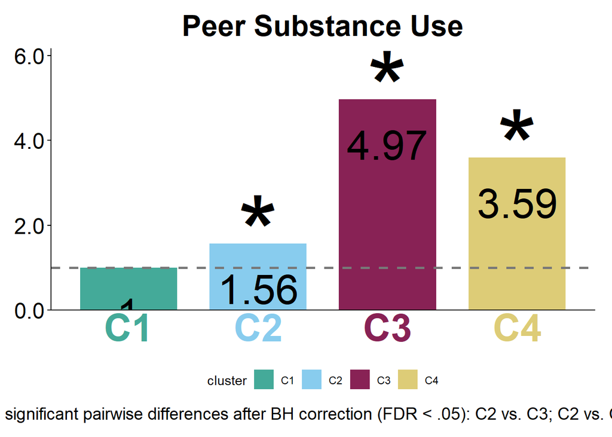

```r
ggsave(file.path(fig_or_c1, "Zpeer_subuse_OR_C1ref.png"),
       plot = p_c1_peer, width = 14, height = 8, dpi = fig_dpi, units = "in")
```

## Figure: Pubertal Timing - C1 Reference

```r
c1_pub <- c1_params %>% filter(predictor_var == "pub_timing")

ref_sig <- c1_pairs %>%
  filter(predictor == "pub_timing",
         cluster_a == 1 | cluster_b == 1,
         sig == TRUE) %>%
  mutate(other = ifelse(cluster_a == 1, cluster_b, cluster_a)) %>%
  pull(other)

other_sig <- c1_pairs %>%
  filter(predictor == "pub_timing",
         cluster_a != 1, cluster_b != 1,
         sig == TRUE) %>%
  mutate(pair = paste0("C", cluster_a, " vs. C", cluster_b)) %>%
  pull(pair)

c1_pub <- c1_pub %>%
  mutate(
    ast_label = ifelse(as.integer(cluster) %in% ref_sig, "*", ""),
    ast_y     = OR + max(OR) * ast_nudge_pct
  )

plot_title  <- "Pubertal Timing"
x_label     <- "Reference: C1"
y_label     <- y_lab
fig_caption <- if (length(other_sig) > 0) {
                 paste0("Additional significant pairwise differences after BH correction (FDR < .05): ",
                        paste(other_sig, collapse = "; "), ".")
             } else {
                 "No additional pairwise differences were significant after BH correction."
}
p_c1_pub <- ggplot(c1_pub, aes(x = cluster, y = OR, fill = cluster)) +
  geom_col(width = bar_width, alpha = bar_alpha,
           linewidth = bar_outline_lwd) +
  geom_hline(yintercept = 1, color = ref_line_color,
             linewidth = ref_line_lwd, linetype = ref_line_type) +
  geom_text(aes(y = OR, label = round(OR, 2)),
            color = or_label_color, size = or_label_size, vjust = or_label_vjust) +
  geom_text(aes(y = ast_y, label = ast_label),
            size = ast_text_size, vjust = 0.5) +
  scale_fill_manual(values = cluster_colors) +
  scale_y_continuous(expand = expansion(mult = c(0, 0.18)),
                     labels = number_format(accuracy = 0.1)) +
  labs(title = plot_title, x = x_label, y = y_label, caption = fig_caption) +
  or_theme + theme(plot.caption    = element_text(size = 14, hjust = .5, face = "plain", family = plot_font,
                                   margin = margin(t = 8)) ,
                   axis.title.y = element_blank(),
                   axis.title.x = element_blank() ,
                 axis.text.x = element_text(size = 32),
                   axis.title = element_text(size = 40) )


print(p_c1_pub)
cat("\n*Caption:*", fig_caption, "\n")
```

```
*Caption:* Additional significant pairwise differences after BH correction (FDR < .05): C2 vs. C3; C2 vs. C4.
```

Figure 3

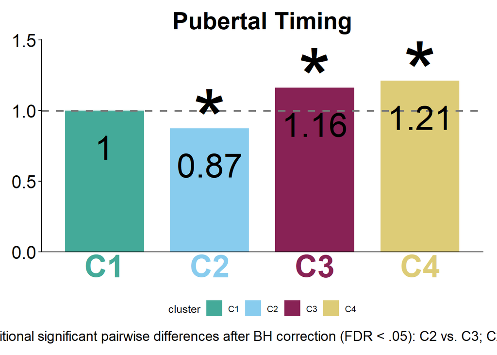

```r
ggsave(file.path(fig_or_c1, "pub_timing_OR_C1ref.png"),
       plot = p_c1_pub, width = 14, height = 8, dpi = fig_dpi, units = "in")
```

## Figure: Autonomy Supportive Parenting - C1 Reference

```r
c1_asp <- c1_params %>% filter(predictor_var == "Zasp")

ref_sig <- c1_pairs %>%
  filter(predictor == "Zasp",
         cluster_a == 1 | cluster_b == 1,
         sig == TRUE) %>%
  mutate(other = ifelse(cluster_a == 1, cluster_b, cluster_a)) %>%
  pull(other)

other_sig <- c1_pairs %>%
  filter(predictor == "Zasp",
         cluster_a != 1, cluster_b != 1,
         sig == TRUE) %>%
  mutate(pair = paste0("C", cluster_a, " vs. C", cluster_b)) %>%
  pull(pair)

c1_asp <- c1_asp %>%
  mutate(
    ast_label = ifelse(as.integer(cluster) %in% ref_sig, "*", ""),
    ast_y     = OR + max(OR) * ast_nudge_pct
  )

plot_title  <- "* Significantly different than C1"
x_label     <- "Reference: C1"
y_label     <- y_lab
fig_caption <- if (length(other_sig) > 0) {
                 paste0("Additional significant pairwise differences after BH correction (FDR < .05): ",
                        paste(other_sig, collapse = "; "), ".")
              } else {
                 "No additional pairwise differences were significant after BH correction."
}
p_c1_asp <- ggplot(c1_asp, aes(x = cluster, y = OR, fill = cluster)) +
  geom_col(width = bar_width, alpha = bar_alpha,
           linewidth = bar_outline_lwd) +
  geom_hline(yintercept = 1, color = "gray20",
             linewidth = ref_line_lwd, linetype = ref_line_type) +
  geom_text(aes(y = OR, label = round(OR, 2)),
            color = or_label_color, size = or_label_size, vjust = or_label_vjust) +
  geom_text(aes(y = ast_y, label = ast_label),
            size = ast_text_size, vjust = 0.5) +
  scale_fill_manual(values = cluster_colors) +
  scale_y_continuous(expand = expansion(mult = c(0, 0.18)),
                     labels = number_format(accuracy = 0.1)) +
  labs(title = plot_title, x = x_label, y = y_label, caption = fig_caption) +
  or_theme +
  theme(
    axis.title.y = element_blank(),
    axis.title.x = element_blank()
  )


print(p_c1_asp)
cat("\n\n*", fig_caption, "*\n\n")
```

```
* Additional significant pairwise differences after BH correction (FDR < .05): C2 vs. C3; C2 vs. C4. *
```

Figure 4

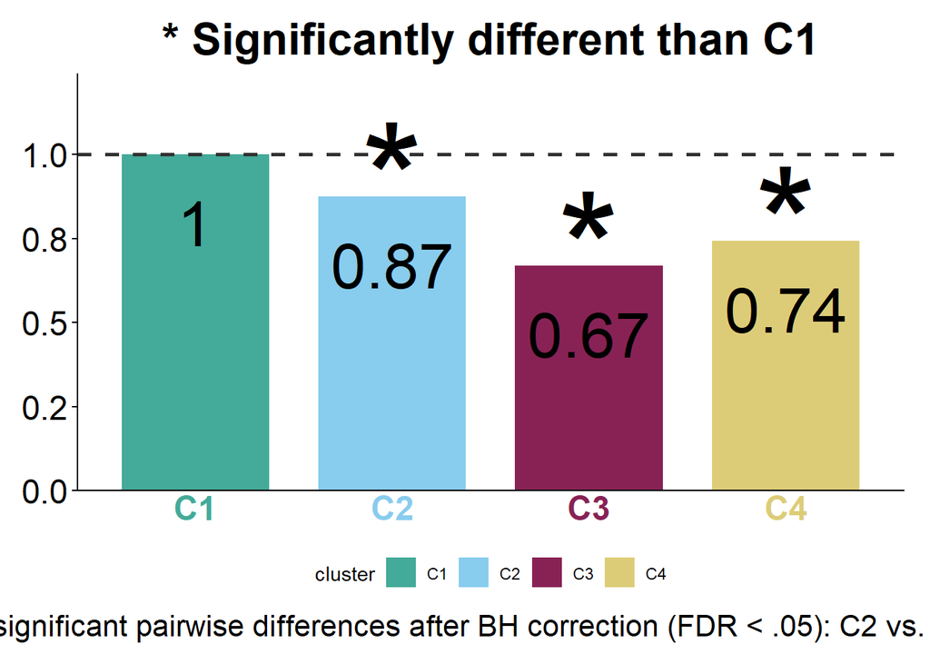

```r
ggsave(file.path(fig_or_c1, "Zasp_OR_C1ref.png"),
       plot = p_c1_asp, width = 3.25, height = 8, dpi = fig_dpi, units = "in",
       bg = "transparent")
```

# Figures: C3 as Reference Group

## Figure: Sex - C3 Reference

```r
c3_sex <- c3_params %>% filter(predictor_var == "female")

ref_sig <- c3_pairs %>%
  filter(predictor == "bio_sexD",
         cluster_a == 3 | cluster_b == 3,
         sig == TRUE) %>%
  mutate(other = ifelse(cluster_a == 3, cluster_b, cluster_a)) %>%
  pull(other)

other_sig <- c3_pairs %>%
  filter(predictor == "bio_sexD",
         cluster_a != 3, cluster_b != 3,
         sig == TRUE) %>%
  mutate(pair = paste0("C", cluster_a, " vs. C", cluster_b)) %>%
  pull(pair)

c3_sex <- c3_sex %>%
  mutate(
    ast_label = ifelse(as.integer(cluster) %in% ref_sig, "*", ""),
    ast_y     = OR + max(OR) * ast_nudge_pct
  )

plot_title  <- "Sex (Female vs. Male)"
#x_label     <- "Reference: C3"
#y_label     <- "Odds Ratio - C3 as Reference"
fig_caption <- if (length(other_sig) > 0) {
                 paste0("Additional significant pairwise differences after BH correction (FDR < .05): ",
                        paste(other_sig, collapse = "; "), ".")
               } else {
                 "No additional pairwise differences were significant after BH correction."
 }
p_c3_sex <- ggplot(c3_sex, aes(x = cluster, y = OR, fill = cluster)) +
  geom_col(width = bar_width, alpha = bar_alpha,
           linewidth = bar_outline_lwd) +
  geom_hline(yintercept = 1, color = ref_line_color,
             linewidth = ref_line_lwd, linetype = ref_line_type) +
  geom_text(aes(y = OR, label = round(OR, 2)),
            color = or_label_color, size = or_label_size, vjust = or_label_vjust) +
  geom_text(aes(y = ast_y, label = ast_label),
            size = ast_text_size, vjust = 0.5) +
  scale_fill_manual(values = cluster_colors) +
  scale_y_continuous(expand = expansion(mult = c(0, 0.18)),
                     labels = number_format(accuracy = 0.1)) +
  labs(title = plot_title, x = x_label, y = y_label, caption = fig_caption) +
  or_theme + theme(plot.caption    = element_text(size = 14, hjust = .5, face = "plain", family = plot_font,
                                   margin = margin(t = 8)) ,
                    axis.title.x = element_blank() ,
                   axis.text.x = element_text(size = 28) ,axis.title.y = element_blank() )


print(p_c3_sex)
cat("\n*Caption:*", fig_caption, "\n")
```

```
*Caption:* Additional significant pairwise differences after BH correction (FDR < .05): C4 vs. C2; C1 vs. C2.
```

Figure 5

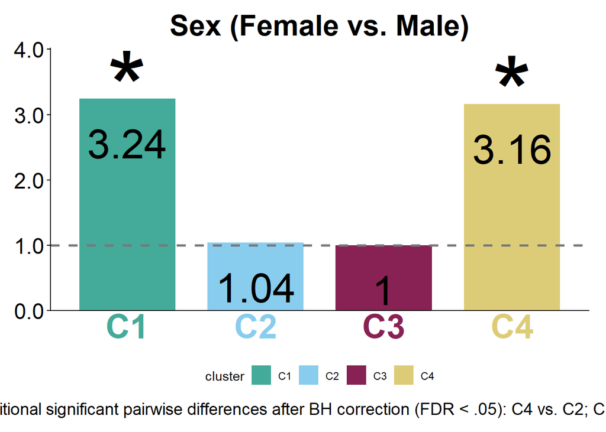

```r
ggsave(file.path(fig_or_c3, "bio_sexD_OR_C3ref.png"),
       plot = p_c3_sex, width = 14, height = 8, dpi = fig_dpi, units = "in")
```

## Figure: Age - C3 Reference

```r
c3_age <- c3_params %>% filter(predictor_var == "Zwave1age")

ref_sig <- c3_pairs %>%
  filter(predictor == "Zwave1age",
         cluster_a == 3 | cluster_b == 3,
         sig == TRUE) %>%
  mutate(other = ifelse(cluster_a == 3, cluster_b, cluster_a)) %>%
  pull(other)

other_sig <- c3_pairs %>%
  filter(predictor == "Zwave1age",
         cluster_a != 3, cluster_b != 3,
         sig == TRUE) %>%
  mutate(pair = paste0("C", cluster_a, " vs. C", cluster_b)) %>%
  pull(pair)

c3_age <- c3_age %>%
  mutate(
    ast_label = ifelse(as.integer(cluster) %in% ref_sig, "*", ""),
    ast_y     = OR + max(OR) * ast_nudge_pct
  )

plot_title  <- "Age"
x_label     <- "Reference: C3"
y_label     <- y_lab
fig_caption <- if (length(other_sig) > 0) {
                 paste0("Additional significant pairwise differences after BH correction (FDR < .05): ",
                        paste(other_sig, collapse = "; "), ".")
               } else {
                 "No additional pairwise differences were significant after BH correction."
 }
p_c3_age<- ggplot(c3_age, aes(x = cluster, y = OR, fill = cluster)) +
  geom_col(width = bar_width, alpha = bar_alpha,
            linewidth = bar_outline_lwd) +
  geom_hline(yintercept = 1, color = ref_line_color,
             linewidth = ref_line_lwd, linetype = ref_line_type) +
  geom_text(aes(y = OR, label = round(OR, 2)),
            color = or_label_color, size = or_label_size, vjust = or_label_vjust) +
  geom_text(aes(y = ast_y, label = ast_label),
            size = ast_text_size, vjust = 0.5) +
  scale_fill_manual(values = cluster_colors) +
  scale_y_continuous(expand = expansion(mult = c(0, 0.18)),
                     labels = number_format(accuracy = 0.1)) +
  labs(title = plot_title, x = x_label, y = y_label, caption = fig_caption) +
  or_theme + theme(plot.caption    = element_text(size = 14, hjust = .5, face = "plain", family = plot_font,
                                   margin = margin(t = 8)) ,
                   axis.title.y = element_blank(),
                   axis.title.x = element_blank() ,
                   axis.text.x = element_text(size = 28) )

print(p_c3_age)
cat("\n*Caption:*", fig_caption, "\n")
```

```
*Caption:* Additional significant pairwise differences after BH correction (FDR < .05): C4 vs. C1; C4 vs. C2; C1 vs. C2.
```

Figure 6

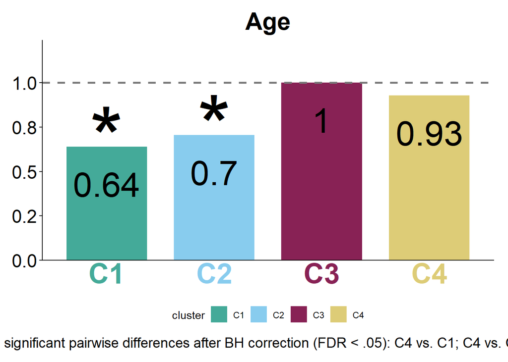

```r
ggsave(file.path(fig_or_c3, "Zwave1age_OR_C3ref.png"),
       plot = p_c3_age, width = 14, height = 8, dpi = fig_dpi, units = "in")
```

## Figure: Peer Substance Use - C3 Reference

```r
c3_peer <- c3_params %>% filter(predictor_var == "Zpeer_subuse")

ref_sig <- c3_pairs %>%
  filter(predictor == "Zpeer_subuse",
         cluster_a == 3 | cluster_b == 3,
         sig == TRUE) %>%
  mutate(other = ifelse(cluster_a == 3, cluster_b, cluster_a)) %>%
  pull(other)

other_sig <- c3_pairs %>%
  filter(predictor == "Zpeer_subuse",
         cluster_a != 3, cluster_b != 3,
         sig == TRUE) %>%
  mutate(pair = paste0("C", cluster_a, " vs. C", cluster_b)) %>%
  pull(pair)

c3_peer <- c3_peer %>%
  mutate(
    ast_label = ifelse(as.integer(cluster) %in% ref_sig, "*", ""),
    ast_y     = OR + max(OR) * ast_nudge_pct
  )

plot_title  <- "Peer Substance Use"
x_label     <- "Reference: C3"
y_label     <- y_lab
fig_caption <- if (length(other_sig) > 0) {
                 paste0("Additional significant pairwise differences after BH correction (FDR < .05): ",
                        paste(other_sig, collapse = "; "), ".")
               } else {
                 "No additional pairwise differences were significant after BH correction."
 }
p_c3_peer <- ggplot(c3_peer, aes(x = cluster, y = OR, fill = cluster)) +
  geom_col(width = bar_width, alpha = bar_alpha,
            linewidth = bar_outline_lwd) +
  geom_hline(yintercept = 1, color = ref_line_color,
             linewidth = ref_line_lwd, linetype = ref_line_type) +
  geom_text(aes(y = OR, label = round(OR, 2)),
            color = or_label_color, size = or_label_size, vjust = or_label_vjust) +
  geom_text(aes(y = ast_y, label = ast_label),
            size = ast_text_size, vjust = 0.5) +
  scale_fill_manual(values = cluster_colors) +
  scale_y_continuous(expand = expansion(mult = c(0, 0.18)),
                     labels = number_format(accuracy = 0.1)) +
  labs(title = plot_title, x = x_label, y = y_label, caption = fig_caption) +
  or_theme + theme(plot.caption    = element_text(size = 14, hjust = .5, face = "plain", family = plot_font,
                                   margin = margin(t = 8)) ,
                   axis.title.y = element_blank(),
                   axis.title.x = element_blank() ,
                   axis.text.x = element_text(size = 28) )

print(p_c3_peer)
cat("\n*Caption:*", fig_caption, "\n")
```

```
*Caption:* Additional significant pairwise differences after BH correction (FDR < .05): C4 vs. C1; C4 vs. C2; C1 vs. C2.
```

Figure 7

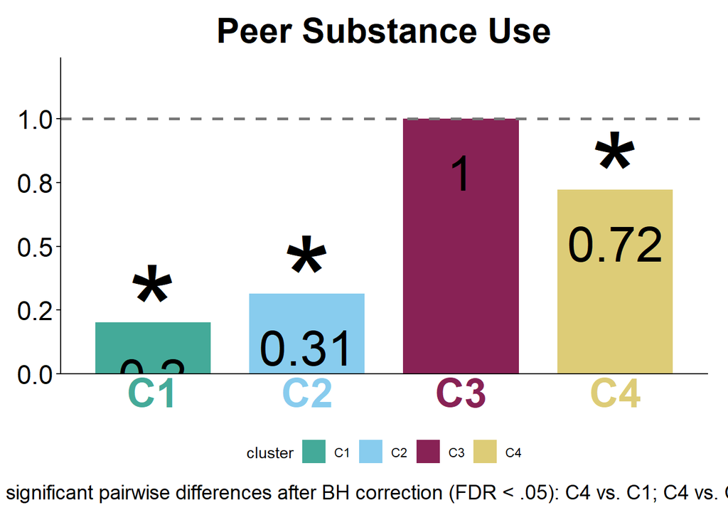

```r
ggsave(file.path(fig_or_c3, "Zpeer_subuse_OR_C3ref.png"),
       plot = p_c3_peer, width = 14, height = 8, dpi = fig_dpi, units = "in")
```

## Figure: Pubertal Timing - C3 Reference

```r
c3_pub <- c3_params %>% filter(predictor_var == "pub_timing")

ref_sig <- c3_pairs %>%
  filter(predictor == "pub_timing",
         cluster_a == 3 | cluster_b == 3,
         sig == TRUE) %>%
  mutate(other = ifelse(cluster_a == 3, cluster_b, cluster_a)) %>%
  pull(other)

other_sig <- c3_pairs %>%
  filter(predictor == "pub_timing",
         cluster_a != 3, cluster_b != 3,
         sig == TRUE) %>%
  mutate(pair = paste0("C", cluster_a, " vs. C", cluster_b)) %>%
  pull(pair)

c3_pub <- c3_pub %>%
  mutate(
    ast_label = ifelse(as.integer(cluster) %in% ref_sig, "*", ""),
    ast_y     = OR + max(OR) * ast_nudge_pct
  )

plot_title  <- "Pubertal Timing"
x_label     <- "Reference: C3"
y_label     <- y_lab
fig_caption <- if (length(other_sig) > 0) {
                 paste0("Additional significant pairwise differences after BH correction (FDR < .05): ",
                        paste(other_sig, collapse = "; "), ".")
               } else {
                 "No additional pairwise differences were significant after BH correction."
 }
p_c3_pub <- ggplot(c3_pub, aes(x = cluster, y = OR, fill = cluster)) +
  geom_col(width = bar_width, alpha = bar_alpha,
            linewidth = bar_outline_lwd) +
  geom_hline(yintercept = 1, color = ref_line_color,
             linewidth = ref_line_lwd, linetype = ref_line_type) +
  geom_text(aes(y = OR, label = round(OR, 2)),
            color = or_label_color, size = or_label_size, vjust = or_label_vjust) +
  geom_text(aes(y = ast_y, label = ast_label),
            size = ast_text_size, vjust = 0.5) +
  scale_fill_manual(values = cluster_colors) +
  scale_y_continuous(expand = expansion(mult = c(0, 0.18)),
                     labels = number_format(accuracy = 0.1)) +
  labs(title = plot_title, x = x_label, y = y_label, caption = fig_caption) +
  or_theme + theme(plot.caption    = element_text(size = 14, hjust = .5, face = "plain", family = plot_font,
                                   margin = margin(t = 8)) ,
                   axis.title.y = element_blank(),
                   axis.title.x = element_blank() ,
                   axis.text.x = element_text(size = 28) )

print(p_c3_pub)
cat("\n*Caption:*", fig_caption, "\n")
```

```
*Caption:* Additional significant pairwise differences after BH correction (FDR < .05): C4 vs. C1; C4 vs. C2; C1 vs. C2.
```

Figure 8

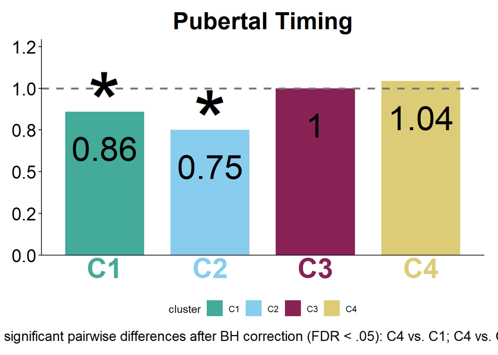

```r
ggsave(file.path(fig_or_c3, "pub_timing_OR_C3ref.png"),
       plot = p_c3_pub, width = 14, height = 8, dpi = fig_dpi, units = "in")
```

## Figure: Autonomy Supportive Parenting - C3 Reference

```r
c3_asp <- c3_params %>% filter(predictor_var == "Zasp")

ref_sig <- c3_pairs %>%
  filter(predictor == "Zasp",
         cluster_a == 3 | cluster_b == 3,
         sig == TRUE) %>%
  mutate(other = ifelse(cluster_a == 3, cluster_b, cluster_a)) %>%
  pull(other)

other_sig <- c3_pairs %>%
  filter(predictor == "Zasp",
         cluster_a != 3, cluster_b != 3,
         sig == TRUE) %>%
  mutate(pair = paste0("C", cluster_a, " vs. C", cluster_b)) %>%
  pull(pair)

c3_asp <- c3_asp %>%
  mutate(
    ast_label = ifelse(as.integer(cluster) %in% ref_sig, "*", ""),
    ast_y     = OR + max(OR) * ast_nudge_pct
  )

plot_title  <- "* Significantly different than C3"
x_label     <- "Reference: C3"
y_label     <- y_lab
fig_caption <- if (length(other_sig) > 0) {
                 paste0("Additional significant pairwise differences after BH correction (FDR < .05): ",
                        paste(other_sig, collapse = "; "), ".")
               } else {
                 "No additional pairwise differences were significant after BH correction."
 }
p_c3_asp <- ggplot(c3_asp, aes(x = cluster, y = OR, fill = cluster)) +
  geom_col(width = bar_width, alpha = bar_alpha,
            linewidth = bar_outline_lwd) +
  geom_hline(yintercept = 1, color = "gray20",
             linewidth = ref_line_lwd, linetype = ref_line_type) +
  geom_text(aes(y = OR, label = round(OR, 2)),
            color = or_label_color, size = or_label_size, vjust = or_label_vjust) +
  geom_text(aes(y = ast_y, label = ast_label),
            size = ast_text_size, vjust = 0.5) +
  scale_fill_manual(values = cluster_colors) +
  scale_y_continuous(expand = expansion(mult = c(0, 0.18)),
                     labels = number_format(accuracy = 0.1)) +
  labs(title = plot_title, x = x_label, y = y_label, caption = fig_caption) +
  or_theme +
  theme(
    axis.title.y = element_blank(),
    axis.title.x = element_blank()
  )

print(p_c3_asp)
cat("\n*Caption:*", fig_caption, "\n")
```

```
*Caption:* Additional significant pairwise differences after BH correction (FDR < .05): C4 vs. C1; C4 vs. C2; C1 vs. C2.
```

Figure 9

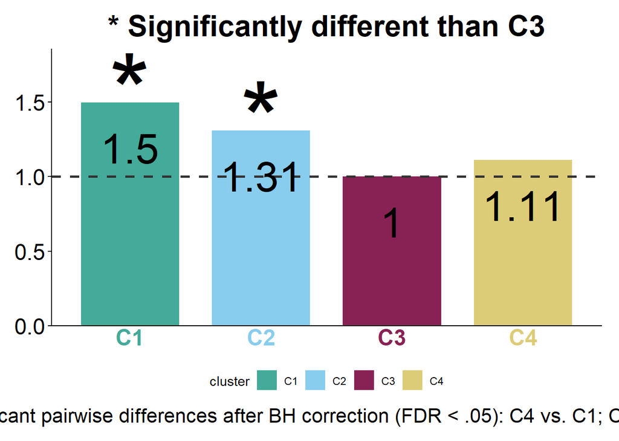

```r
ggsave(file.path(fig_or_c3, "Zasp_OR_C3ref.png"),
       plot = p_c3_asp, width = 3.25, height = 8, dpi = fig_dpi, units = "in",
       bg = "transparent")
```

# Figure Labels

```r
library(ggplot2)

legend_labels <- c(
  "C1"      = "C1: High PR - Low NR (35.6%)",
  "C2"      = "C2: Low PR - Low NR (33.7%)",
  "C3"      = "C3: Low PR - High NR(15.8%)",
  "C4"      = "C4: High PR - High PR (14.9%)"
)

dummy_df <- data.frame(
  x       = 1:4,
  y       = 1:4,
  cluster = factor(names(legend_labels), levels = names(legend_labels))
)

p <- ggplot(dummy_df, aes(x = x, y = y, fill = cluster)) +
  geom_col() +
  scale_fill_manual(values = cluster_colors, labels = legend_labels, name = NULL) +
  guides(fill = guide_legend(ncol = 1, keywidth = 1.2, keyheight = 1.2)) +
  coord_cartesian(ylim = c(100, 101)) +   # pushes bars completely out of view
  theme_void() +
  theme(
    legend.position.inside = c(0.5, 0.5),
    legend.position        = "inside",
    legend.text            = element_text(size = 14),
    legend.spacing.y       = unit(6, "pt")
  )

ggsave(file.path(fig_or_c1, "legend_only.png"),
       plot = p, width = 14, height = 8, dpi = 300, units = "in")
```

```r
legend_labels2 <- c(
  "C1"      = "C1: Adaptive Risk-Takers     | High PR-Low NR (35.6%)",
  "C2"      = "C2: Low Risk-Takers            | Low PR-Low NR (33.7%)",
  "C3"      = "C3: Maldaptive Risk-Takers | Low PR-High NR (15.8%)",
  "C4"      = "C4: High Risk-Takers           | High PR-High NR (14.9%)"
)

dummy_df2 <- data.frame(
  x       = 1:4,
  y       = 1:4,
  cluster = factor(names(legend_labels2), levels = names(legend_labels2))
)

p2 <- ggplot(dummy_df2, aes(x = x, y = y, fill = cluster)) +
  geom_col() +
  scale_fill_manual(values = cluster_colors, labels = legend_labels2, name = NULL) +
  guides(fill = guide_legend(ncol = 1, keywidth = 1.2, keyheight = 1.2)) +
  coord_cartesian(ylim = c(100, 101)) +   # pushes bars completely out of view
  theme_void() +
  theme(
    legend.position.inside = c(0.5, 0.5),
    legend.position        = "inside",
    legend.text            = element_text(size = 14),
    legend.spacing.y       = unit(6, "pt")
  )

ggsave(file.path(fig_or_c1, "legend_only2.png"),
       plot = p2, width = 8, height = 4, dpi = 300, units = "in")

p3 <- ggplot(dummy_df2, aes(x = x, y = y, fill = cluster)) +
  geom_col() +
  scale_fill_manual(values = cluster_colors, labels = legend_labels2, name = NULL) +
  guides(fill = guide_legend(ncol = 2, keywidth = 1.2, keyheight = 1.2)) +
  coord_cartesian(ylim = c(100, 101)) +   # pushes bars completely out of view
  theme_void() +
  theme(
    legend.position.inside = c(0.5, 0.5),
    legend.position        = "inside",
    legend.text            = element_text(size = 14),
    legend.spacing.y       = unit(6, "pt")
  )

ggsave(file.path(fig_or_c1, "legend_only3.png"),
       plot = p3, width = 14, height = 8, dpi = 300, units = "in")
```

## Draft Figure Notes

**C1 as Reference Group**

*Figure X.* Odds ratios for [predictor] predicting profile membership relative to C1 (reference group, OR = 1.0). Sex was dummy-coded (0 = male, 1 = female); all continuous predictors were standardized (*M* = 0, *SD* = 1). Asterisks (*) indicate profiles whose odds ratio differs significantly from C1 after Benjamini-Hochberg false discovery rate correction (FDR < .05). Omnibus Wald test *p*-values are reported without correction for multiple comparisons.

**C3 as Reference Group**

*Figure X.* Odds ratios for [predictor] predicting profile membership relative to C3 (reference group, OR = 1.0). Sex was dummy-coded (0 = male, 1 = female); all continuous predictors were standardized (*M* = 0, *SD* = 1). Asterisks (*) indicate profiles whose odds ratio differs significantly from C3 after Benjamini-Hochberg false discovery rate correction (FDR < .05). Omnibus Wald test *p*-values are reported without correction for multiple comparisons.

Back to top